# WIN PREDICTION

## Problem Statement

Your Organization puts in a lot of effort in bidding preparation with no indications whether it will be worth it. With multiple managers and VP willing to work on every opportunity, it becomes difficult for the management to decide which bid should be given to which manager and VP. You are hired to help your organization identify the best manager-VP combination who can convert an opportunity to win with the provided data points.

#### Objective 1: Predictive Analytics - Build a ML model to predict the probability of win/loss for bidding activities for a potential client.

#### Objective 2: Prescriptive Analytics – Identify variable/s that are most likely to help in converting an opportunity into a win.

## Data Dictionary

1. Client Category Industry in which the client works
2. Solution Type The solution group the client requires
3. Deal Date The date the opportunity was created
4. Sector The sector for which the solution is to be provided
5. Location Client location
6. VP Name Sr. Manager or VP whi is dealing with the client
7. Manager Name Manager of the team working on the project
8. Deal Cost The initial cost of the deal
9. Deal Status Code Final status of the deal(won/lost)

## Project Outline

# Understand nature of the data .info() .describe() # Histograms and boxplots # Value counts # Missing data # Correlation between the metrics # Explore interesting themes # Feature engineering # preprocess data together or use a transformer? # use label for train and test # Scaling? # Model Baseline # Model comparison with CV

## 1. Load libraries

```python
#Import Libraries
import pandas as pd
import numpy as np
import matplotlib.pyplot as plt
import seaborn as sns
%matplotlib inline
#Display all the columns of the dataframe
pd.pandas.set_option('display.max_columns', None)

import warnings
warnings.filterwarnings('ignore')
```

## 2. EDA

```python
data=pd.read_excel('Win_Prediction_Data.xlsx')
data_orig=data.copy()
```

```python
## print shape of dataset with rows and columns
print(data.shape)
```

```
(10061, 9)
```

```python
## Print the name of the dataset columns
print(data.columns)
```

```
Index(['Client Category', 'Solution Type', 'Deal Date', 'Sector', 'Location',
       'VP Name', 'Manager Name', 'Deal Cost', 'Deal Status Code'],
      dtype='object')
```

```python
## Print the dataset head
data.head()
```

|  | Client Category | Solution Type | Deal Date | Sector | Location | VP Name | Manager Name | Deal Cost | Deal Status Code |
| --- | --- | --- | --- | --- | --- | --- | --- | --- | --- |
| 0 | Telecom | Solution 7 | 2012-03-27 | Sector 24 | L5 | Ekta Zutshi | Gopa Trilochana | 150000.00 | Won |
| 1 | Telecom | Solution 7 | 2012-09-25 | Sector 24 | L5 | Ekta Zutshi | Gopa Trilochana | 744705.88 | Won |
| 2 | Internal | Solution 59 | 2011-08-01 | Sector 20 | Others | Ekta Zutshi | Russell Dahlen | 60000.00 | Lost |
| 3 | Internal | Solution 59 | 2011-04-28 | Sector 20 | Others | Ekta Zutshi | Russell Dahlen | 60000.00 | Lost |
| 4 | Internal | Solution 32 | 2011-06-03 | Sector 20 | Others | Ekta Zutshi | Russell Dahlen | 80882.35 | Lost |

```python
data.info()
```

```
<class 'pandas.core.frame.DataFrame'>
RangeIndex: 10061 entries, 0 to 10060
Data columns (total 9 columns):
 #   Column            Non-Null Count  Dtype
---  ------            --------------  -----
 0   Client Category   9982 non-null   object
 1   Solution Type     10061 non-null  object
 2   Deal Date         10061 non-null  datetime64[ns]
 3   Sector            10061 non-null  object
 4   Location          10061 non-null  object
 5   VP Name           10061 non-null  object
 6   Manager Name      10061 non-null  object
 7   Deal Cost         10061 non-null  float64
 8   Deal Status Code  10061 non-null  object
dtypes: datetime64[ns](1), float64(1), object(7)
memory usage: 707.5+ KB
```

```python
data.dtypes
```

```
Client Category             object
Solution Type               object
Deal Date           datetime64[ns]
Sector                      object
Location                    object
VP Name                     object
Manager Name                object
Deal Cost                  float64
Deal Status Code            object
dtype: object
```

### Observations till now:

```python
data.describe()
```

|  | Deal Cost |
| --- | --- |
| count | 1.006100e+04 |
| mean | 7.668969e+05 |
| std | 1.619894e+06 |
| min | 0.000000e+00 |
| 25% | 1.897059e+05 |
| 50% | 3.823529e+05 |
| 75% | 7.647059e+05 |
| max | 3.676471e+07 |

```python
data['Client Category'].replace({'Energy ': 'Energy'}, inplace=True)
#List of categorical variables
cat_data=['Client Category', 'Solution Type', 'Sector', 'Location']
#List of numerical variables
num_data=['Deal Cost']
#Target variable
target=['Deal Status Code']
#VP + Manager Names
Names_data=['VP Name', 'Manager Name']
#Date Data
date_data=['Deal Date']
```

```python
print('Categorical variables :',cat_data )
print('Numerical variables :',num_data )
```

```
Categorical variables : ['Client Category', 'Solution Type', 'Sector', 'Location']
Numerical variables : ['Deal Cost']
```

```python
#Check whether the data is balanced
data[target].value_counts(normalize=True)
```

```
Deal Status Code
Lost                0.626777
Won                 0.373223
dtype: float64
```

We may consider the dataset balanced

```python
data.isnull().sum()
```

```
Client Category     79
Solution Type        0
Deal Date            0
Sector               0
Location             0
VP Name              0
Manager Name         0
Deal Cost            0
Deal Status Code     0
dtype: int64
```

### (3.1) For numeric data

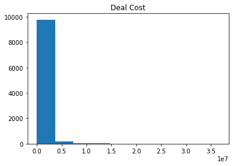

```python
#distributions for all numeric variables
for i in num_data:
    plt.hist(data[i])
    plt.title(i)
    plt.show()
```

```python
#custom function for easy and efficient analysis of numerical univariate

def UVA_numeric(data, var_group):


    size = len(var_group)


    #looping for each variable
    for j,i in enumerate(var_group):

        plt.figure(figsize = (7*size,5), dpi = 100)

        # calculating descriptives of variable
        mini = data[i].min()
        maxi = data[i].max()
        ran = data[i].max()-data[i].min()
        mean = data[i].mean()
        median = data[i].median()
        st_dev = data[i].std()
        skew = data[i].skew()
        kurt = data[i].kurtosis()

        # calculating points of standard deviation
        points = mean-st_dev, mean+st_dev

        #Plotting the variable with every information
        plt.subplot(1,size,j+1)
        sns.kdeplot(data[i], shade=True)
        sns.lineplot(points, [0,0], color = 'black', label = "std_dev")
        plt.axvline(mini , color='orange', ls=':', label='Min')
        plt.axvline(maxi, color='yellow', ls=':', label='Max')
        plt.axvline(mean, color='red', ls=':', label='Mean')
        plt.axvline(median, color='green', ls=':', label='Median')

        plt.legend()
        plt.xlabel('{}'.format(i), fontsize = 20)
        plt.ylabel('density')
        plt.title('std_dev = {}; kurtosis = {};\nskew = {}; range = {}\nmean = {}; median = {}'.format((round(points[0],2),round(points[1],2)),
                                                                                                       round(kurt,2),
                                                                                                       round(skew,2),
                                                                                                       (round(mini,2),round(maxi,2),round(ran,2)),
                                                                                                       round(mean,2),
                                                                                                       round(median,2)))
```

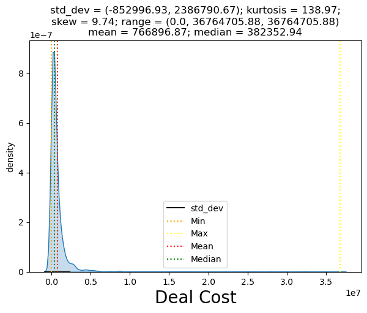

```python
UVA_numeric(data, num_data)
```

Non Normal distribution for Deal cost Highly skewed ==> We should consider Normalize data or Deal with outliers

### (3.2) For Categorical Data

- Made bar charts to understand balance of classes
- Made pivot tables to understand relationship with target

```python
for fet in cat_data:
    data[fet] = data[fet].astype('category')
```

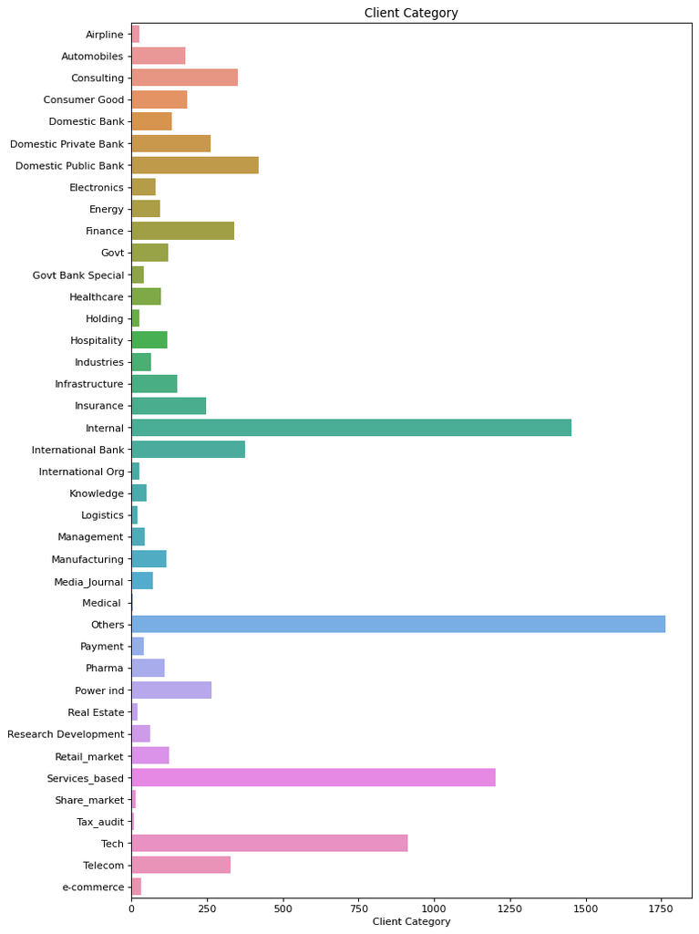

```
Others                   1763
Internal                 1454
Services_based           1202
Tech                      913
Domestic Public Bank      419
International Bank        376
Consulting                352
Finance                   339
Telecom                   327
Power ind                 264
Domestic Private Bank     262
Insurance                 247
Consumer Good             185
Automobiles               178
Infrastructure            152
Domestic Bank             134
Retail_market             126
Govt                      121
Hospitality               119
Manufacturing             117
Pharma                    110
Healthcare                 99
Energy                     94
Electronics                81
Media_Journal              71
Industries                 66
Research Development       63
Knowledge                  50
Management                 43
Govt Bank Special          41
Payment                    40
e-commerce                 32
Airpline                   27
Holding                    25
International Org          25
Logistics                  20
Real Estate                19
Share_market               14
Tax_audit                   7
Medical                     5
Name: Client Category, dtype: int64
```

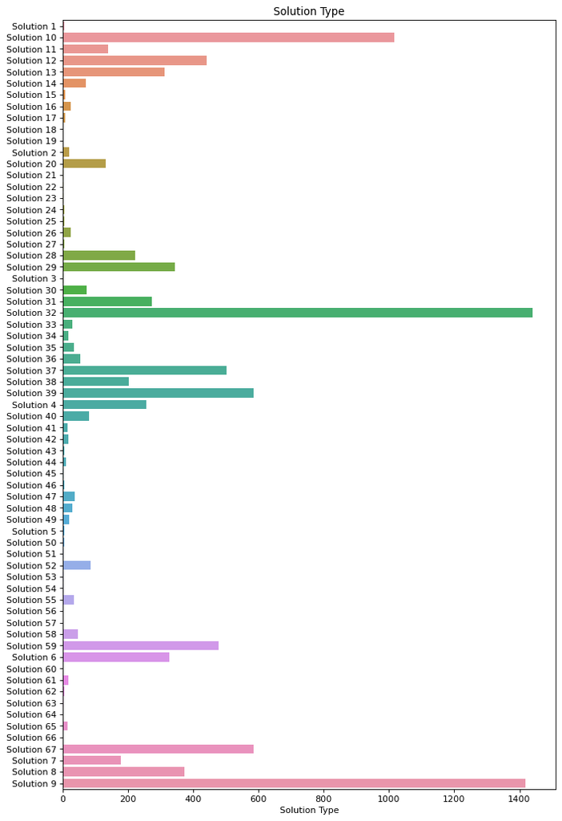

```
Solution 32    1439
Solution 9     1418
Solution 10    1016
Solution 39     585
Solution 67     584
               ...
Solution 19       1
Solution 66       1
Solution 57       1
Solution 56       1
Solution 18       1
Name: Solution Type, Length: 67, dtype: int64
```

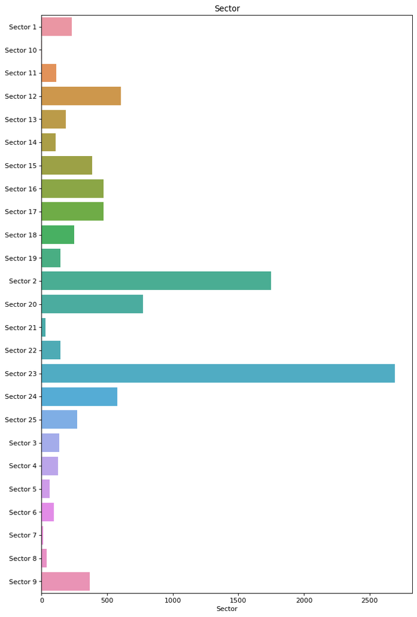

```
Sector 23    2693
Sector 2     1748
Sector 20     773
Sector 12     607
Sector 24     578
Sector 17     474
Sector 16     474
Sector 15     387
Sector 9      369
Sector 25     273
Sector 18     251
Sector 1      231
Sector 13     185
Sector 22     144
Sector 19     142
Sector 3      135
Sector 4      128
Sector 11     114
Sector 14     109
Sector 6       96
Sector 5       64
Sector 8       39
Sector 21      30
Sector 7       14
Sector 10       3
Name: Sector, dtype: int64
```

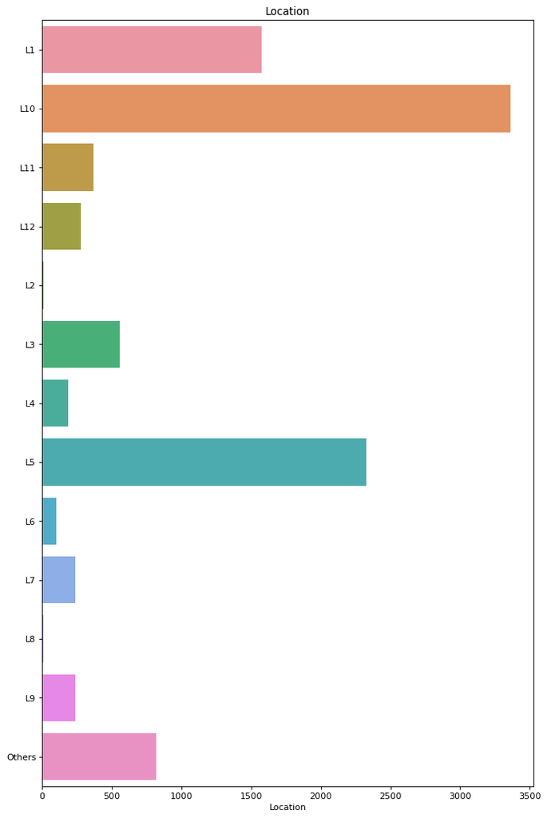

```
L10       3360
L5        2328
L1        1572
Others     817
L3         556
L11        367
L12        276
L9         240
L7         238
L4         188
L6         100
L8          11
L2           8
Name: Location, dtype: int64
```

```python
# setting figure_size
from matplotlib.pyplot import figure
#plt.figure(figsize=(20,10), dpi=100)
for i in  cat_data:
    figure(figsize=(10,16), dpi=80)
    sns.barplot(data[i].value_counts(),data[i].value_counts().index ).set_title(i)
    plt.show()
    print(data[i].value_counts())
```

Observations: Most frequent client category: Internal/ Service-base / Tech Most frequent sectors 23/2 / 20/12 Most freqeunt locations L10 L5 L1 Most frequent solution type 32 9 10 39 Some variables are very messy. This is an area where we may want to do some feature engineering!

```python
# Comparing survival and each of these categorical variables
#['Client Category', 'Solution Type', 'Sector','Deal Date', 'Location','VP Name', 'Manager Name']
print(pd.pivot_table(data, index = 'Deal Status Code', columns = 'Sector', values = 'Deal Cost' ))
```

```
Sector                 Sector 1  Sector 10      Sector 11      Sector 12  \
Deal Status Code
Lost              613037.974810   29411.77  739172.366977  535514.343744
Won               524375.504795  311176.47  388245.799286  739632.719204

Sector               Sector 13      Sector 14      Sector 15     Sector 16  \
Deal Status Code
Lost              1.421940e+06  362345.768049  813788.336154  1.255285e+06
Won               6.606916e+05  544716.777037  438658.208824  6.957036e+05

Sector               Sector 17      Sector 18      Sector 19       Sector 2  \
Deal Status Code
Lost              7.797553e+05  832332.421860  727485.995714  895682.700642
Won               1.027609e+06  775491.437342  448189.655172  802698.875503

Sector               Sector 20   Sector 21      Sector 22      Sector 23  \
Deal Status Code
Lost              6.549127e+05  210705.884  494660.131556  558666.786695
Won               1.213838e+06  229794.118  523050.109444  669064.577854

Sector               Sector 24      Sector 25       Sector 3       Sector 4  \
Deal Status Code
Lost              1.274191e+06  494263.053820  509679.739333  721584.224773
Won               1.204060e+06  418922.600842  390013.072000  404661.765500

Sector                 Sector 5       Sector 6       Sector 7       Sector 8  \
Deal Status Code
Lost              463857.466538  466318.786129  852941.176667  462215.686667
Won               201715.686667  354636.679118  352500.000000  276143.788889

Sector                Sector 9
Deal Status Code
Lost              8.439487e+05
Won               1.180248e+06
```

Deal Cost winnings was registered : * Maximum Sector 20

```
                                 * Minimum Sector 5
```

Deal Cost loses was registred in Sector : * Maximum 13

```
                                       * Minimum  10
```

```python
print(pd.pivot_table(data, index = 'Deal Status Code', columns = 'Client Category', values = 'Deal Cost' ))
```

```
Client Category        Airpline    Automobiles    Consulting  Consumer Good  \
Deal Status Code
Lost              482887.701818  706355.042679  6.088462e+05  629885.954898
Won               549411.768000  537281.641061  1.528884e+06  859452.332644

Client Category   Domestic Bank  Domestic Private Bank  Domestic Public Bank  \
Deal Status Code
Lost               1.495498e+06          881407.086023          1.070093e+06
Won                1.919716e+06          688611.491860          5.993003e+05

Client Category     Electronics        Energy        Finance           Govt  \
Deal Status Code
Lost              553812.637407  1.154716e+06  530710.997739  932606.018837
Won               596633.987407  7.424221e+05  451173.773211  450806.723143

Client Category   Govt Bank Special     Healthcare       Holding  Hospitality  \
Deal Status Code
Lost                    623658.0875  361522.491471  9.430672e+05  385575.7200
Won                     226339.8700  613007.592258  1.504840e+06  250388.2352

Client Category      Industries  Infrastructure     Insurance      Internal  \
Deal Status Code
Lost              506777.494783   795354.278636  1.521391e+06  1.042892e+06
Won               370602.941000   557784.926719  2.911978e+05  9.973580e+05

Client Category   International Bank  International Org      Knowledge  \
Deal Status Code
Lost                   713409.586667      779625.669091  307385.621111
Won                    917279.412063      922549.020000  302205.883571

Client Category     Logistics     Management  Manufacturing  Media_Journal  \
Deal Status Code
Lost              616911.7650  154224.599091  811139.706000  534467.789048
Won               351102.9425  109313.727143  378624.801351  470517.241724

Client Category     Medical          Others      Payment         Pharma  \
Deal Status Code
Lost              498088.235  599736.022085  1280098.040  873235.294615
Won               141176.470  650506.199715   431058.824  883198.529687

Client Category      Power ind    Real Estate  Research Development  \
Deal Status Code
Lost              9.021130e+05  471428.572857         313631.713478
Won               1.236523e+06  291764.706000         343373.701765

Client Category   Retail_market  Services_based  Share_market  Tax_audit  \
Deal Status Code
Lost              567291.898302   537604.830680    154411.765  421568.63
Won               425058.824000   565286.188578     94558.823  397058.82

Client Category            Tech       Telecom     e-commerce
Deal Status Code
Lost              656327.451533  1.299476e+06  378970.589000
Won               518243.751629  1.343050e+06  636151.960833
```

[output not shown]

Deal Cost loses was registred in Sector : * Maximum Insurance

[output not shown]

```python
print(pd.pivot_table(data, index = 'Deal Status Code', columns = 'Solution Type', values = 'Deal Cost' ))
```

```
Solution Type     Solution 1    Solution 10   Solution 11    Solution 12  \
Deal Status Code
Lost               224117.65  676461.210986  1.543663e+06  825068.800058
Won                150196.08  594538.975828  3.059717e+06  897737.095714

Solution Type       Solution 13   Solution 14    Solution 15    Solution 16  \
Deal Status Code
Lost              826709.730748  1.018263e+06  889215.686667  608529.412222
Won               702220.889286  5.171639e+05  347794.115000  650735.295000

Solution Type      Solution 17  Solution 18  Solution 19     Solution 2  \
Deal Status Code
Lost              1.029412e+06          NaN          NaN  651102.942500
Won               6.669118e+05     225000.0    485294.12  390481.284545

Solution Type       Solution 20  Solution 21  Solution 22  Solution 23  \
Deal Status Code
Lost              229715.687000    588235.29    235294.12    294117.65
Won               224571.078333          NaN     88235.29          NaN

Solution Type     Solution 24    Solution 25    Solution 26  Solution 27  \
Deal Status Code
Lost                      NaN  500000.000000  456596.637143    147058.82
Won                238235.296  372549.023333  327794.119000          NaN

Solution Type       Solution 28    Solution 29  Solution 3   Solution 30  \
Deal Status Code
Lost              461659.405062  850397.782459   147058.82  2.101471e+06
Won               185642.158000  551277.480909   485294.12  2.409431e+06

Solution Type       Solution 31    Solution 32    Solution 33   Solution 34  \
Deal Status Code
Lost              635972.626931  483410.073834  520168.067143  9.390756e+05
Won               861540.033611  827868.823112  407812.500000  2.123235e+06

Solution Type      Solution 35   Solution 36    Solution 37    Solution 38  \
Deal Status Code
Lost              9.730392e+05  1.690368e+06  746323.529684  629558.823750
Won               1.203075e+06  5.319910e+05  760158.128548  330419.608667

```

[output cut: 29 more lines]

```

Solution Type     Solution 60   Solution 61  Solution 62  Solution 63  \
Deal Status Code
Lost                      NaN  2.458824e+06  2794117.650   2205882.35
Won                1322352.94  1.279816e+06  3708970.585          NaN

Solution Type     Solution 64  Solution 65  Solution 66    Solution 67  \
Deal Status Code
Lost                      NaN  1647058.820          NaN  837821.511176
Won                 640588.24   913411.767    185294.12  648808.489830

Solution Type       Solution 7    Solution 8     Solution 9
Deal Status Code
Lost              1.000188e+06  7.546873e+05  659805.270314
Won               5.597296e+05  1.095985e+06  602606.618200
```

[output not shown]

[output not shown]

```python
print(pd.pivot_table(data, index = 'Deal Status Code', columns = 'Location', values = 'Deal Cost' ))
```

```
Location                     L1            L10            L11           L12  \
Deal Status Code
Lost              568322.368838  838808.757964  394284.990431  1.152743e+06
Won               788830.659970  784242.842699  541379.085778  6.652551e+05

Location                    L2             L3             L4             L5  \
Deal Status Code
Lost              1.205882e+06  482105.089944  586475.257143  793381.085661
Won               7.132353e+05  384011.765300  416465.845161  784038.147735

Location                     L6             L7           L8             L9  \
Deal Status Code
Lost              686176.471429  538164.300575  1461764.704  592328.684845
Won               316196.079000  466530.331250    73529.410  348299.234130

Location                Others
Deal Status Code
Lost              1.065552e+06
Won               1.303086e+06
```

Deal Cost winnings was registered : * Maximum Others

```
                                 * Minimum L8
```

[output not shown]

```python
def Boxplot_Bivariate(data, cont, cat):
    figure(figsize=(15,10),dpi=80)
    sns.boxplot(x=cat, y=cont, data=data)
    plt.title('Bivariate boxplot')
    plt.show()
```

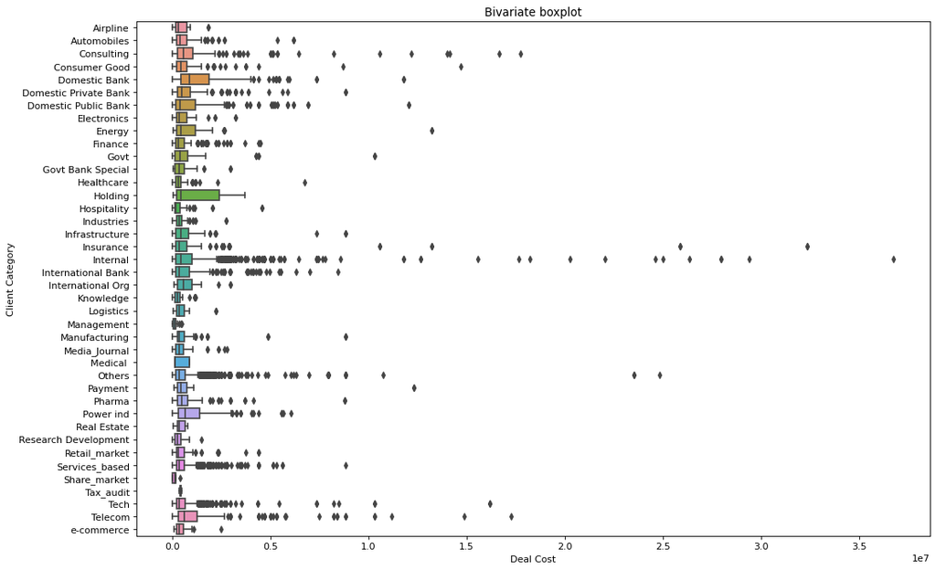

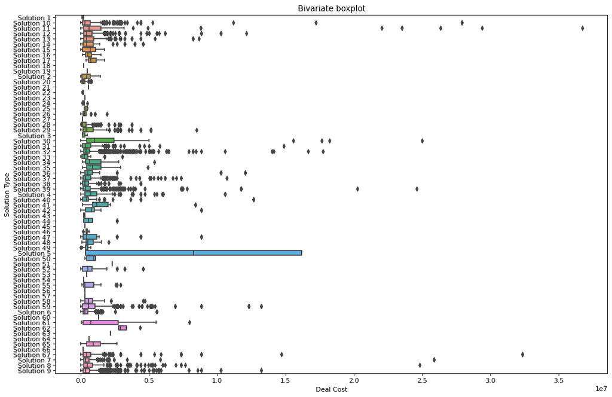

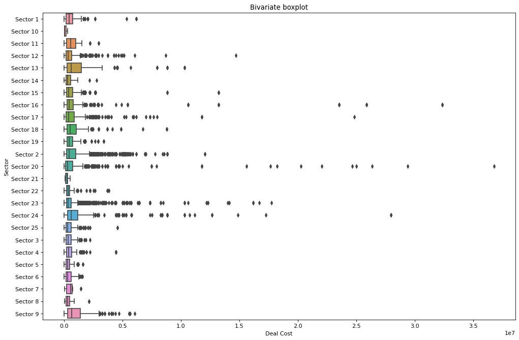

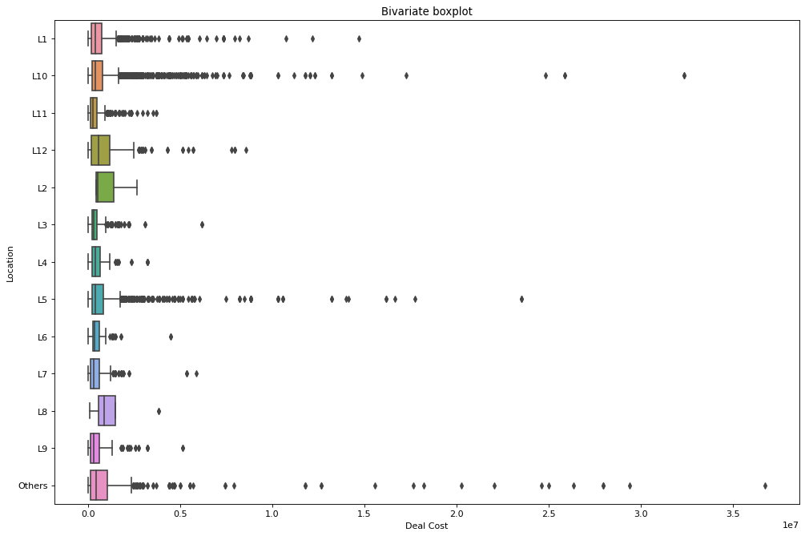

```python
for col2 in cat_data:
        Boxplot_Bivariate(data, col2, 'Deal Cost' )
```

```python
def BVA_categorical_plot(data, tar, cat):
  '''
  take data and two categorical variables,
  calculates the chi2 significance between the two variables
  and prints the result with countplot
  '''
  #isolating the variables
  data = data[[cat,tar]][:]

  #forming a crosstab
  table = pd.crosstab(data[tar],data[cat],)
  f_obs = np.array([table.iloc[0][:].values,
                    table.iloc[1][:].values])

  #performing chi2 test
  from scipy.stats import chi2_contingency
  chi, p, dof, expected = chi2_contingency(f_obs)

  #checking whether results are significant
  if p<0.05:
    sig = True
  else:
    sig = False

  #plotting grouped plot
  figure(figsize=(10,15),dpi=80)
  sns.countplot(y=cat, hue=tar, data=data, orient='h')
  plt.title("p-value = {}\n difference significant? = {}\n".format(round(p,8),sig))

  #plotting percent stacked bar plot
  #sns.catplot(ax, kind='stacked')
  figure(figsize=(15,10),dpi=80)
  ax1 = data.groupby(cat)[tar].value_counts(normalize=True).unstack()
  ax1.plot(kind='bar', stacked='True',title=str(ax1),figsize=(15,10))
  int_level = data[cat].value_counts()
```

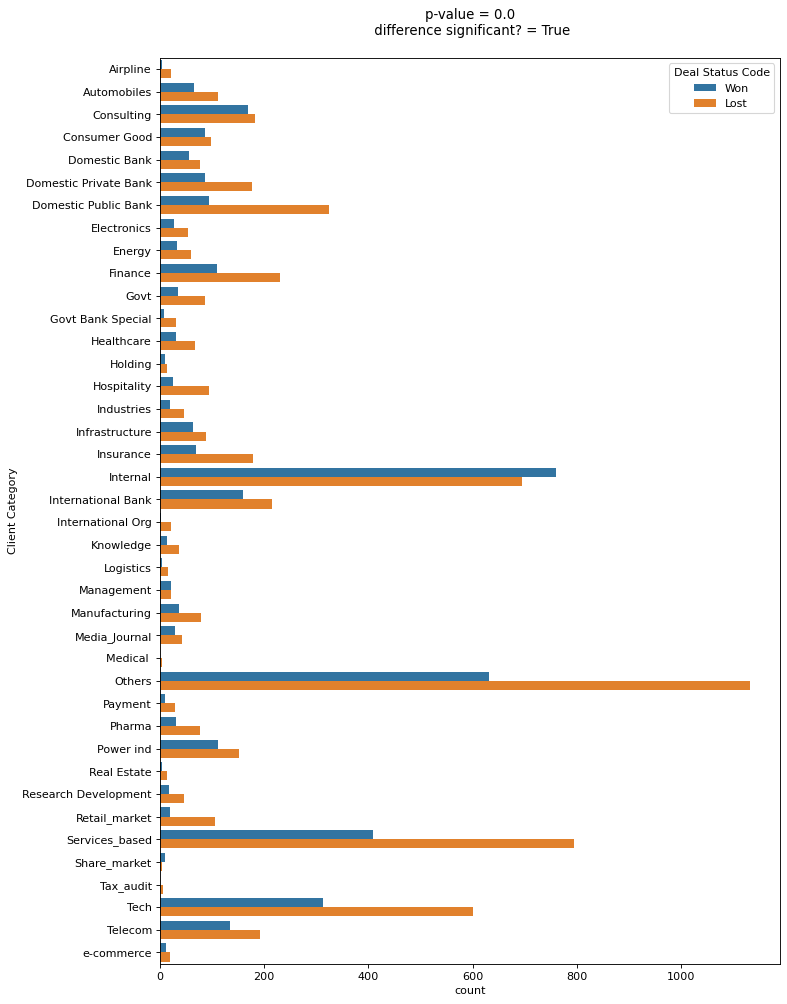

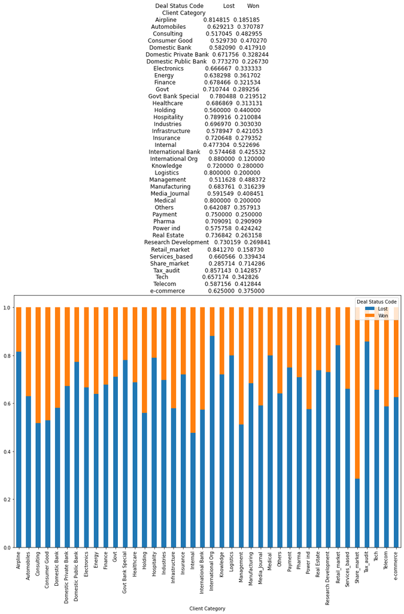

```python
BVA_categorical_plot(data,'Deal Status Code','Client Category')
```

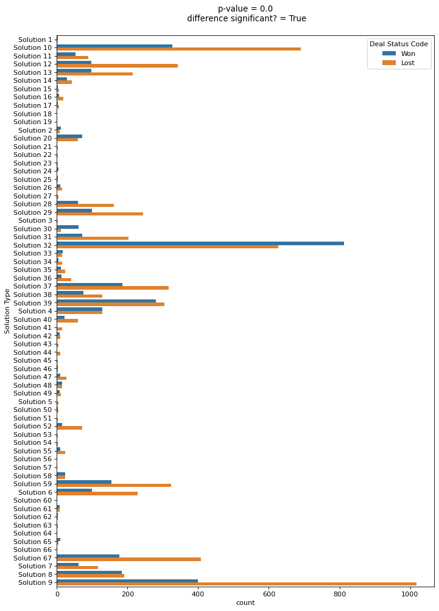

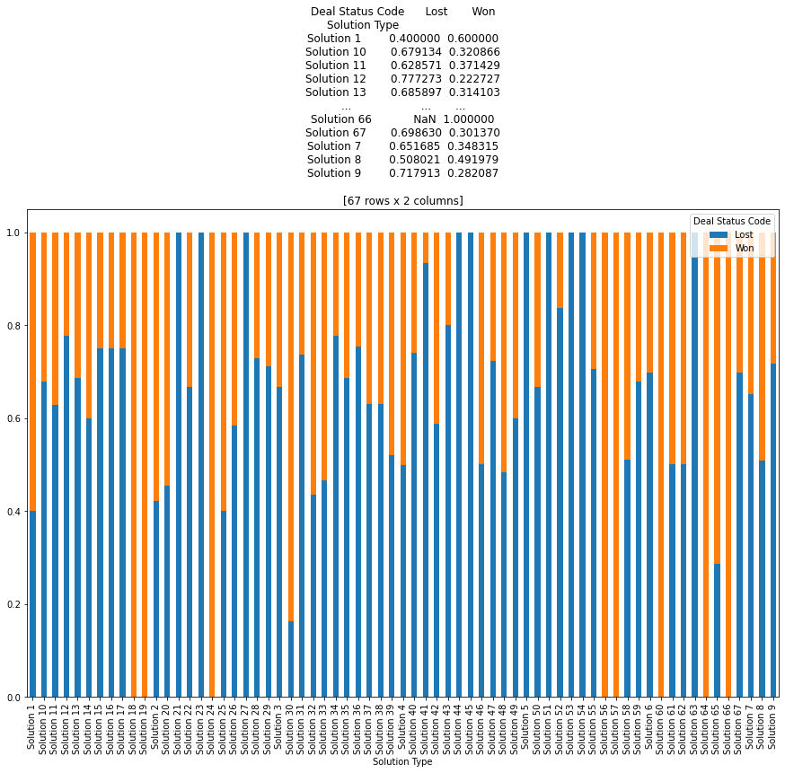

```python
BVA_categorical_plot(data,'Deal Status Code','Solution Type')
```

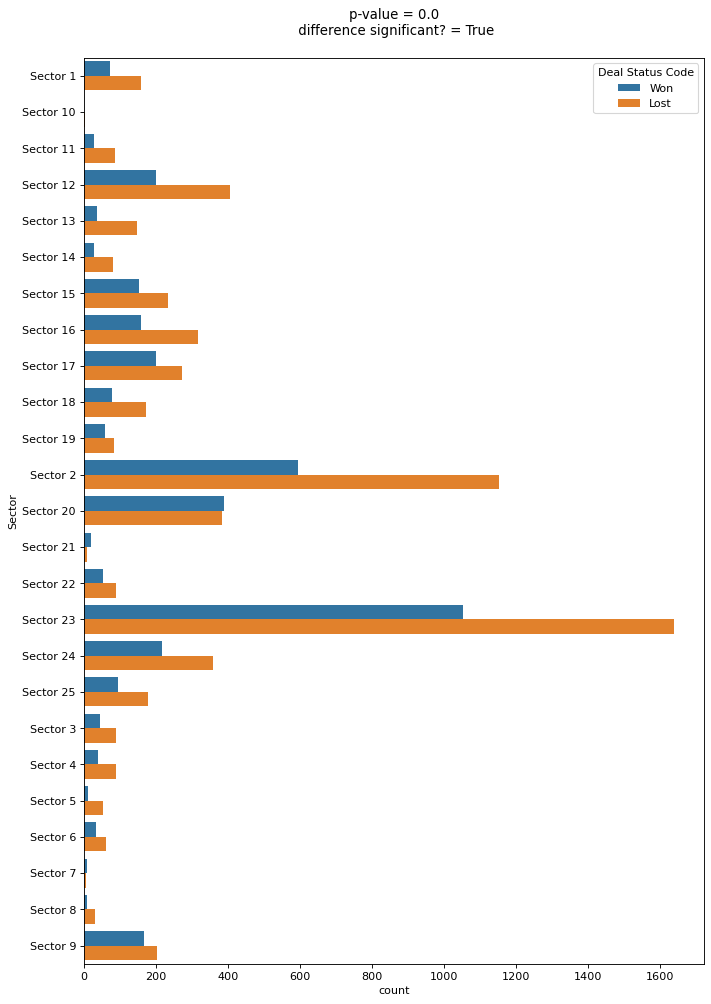

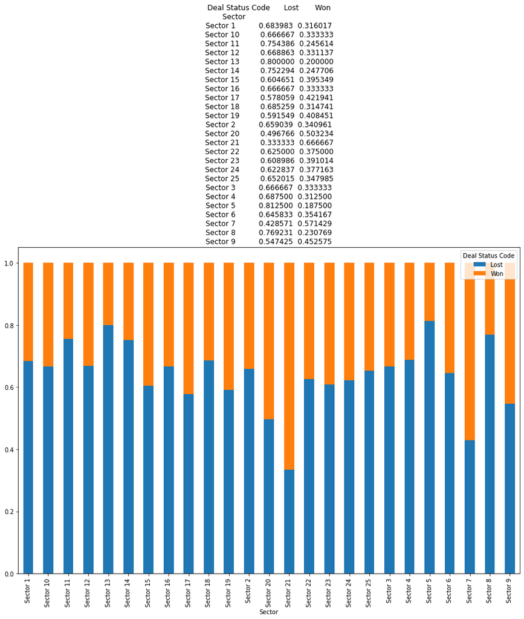

```python
BVA_categorical_plot(data,'Deal Status Code', 'Sector')
```

```python
#BVA_categorical_plot(data,'Deal Status Code', 'Manager Name')
```

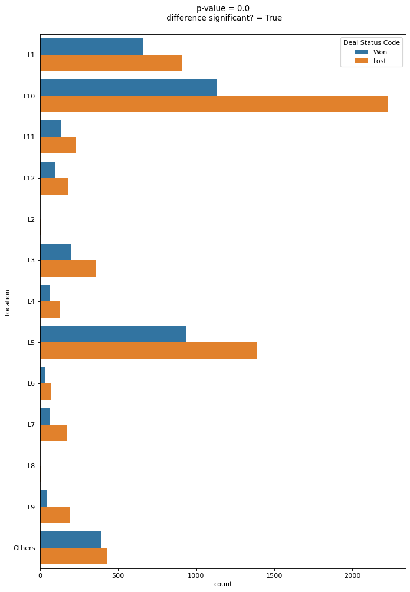

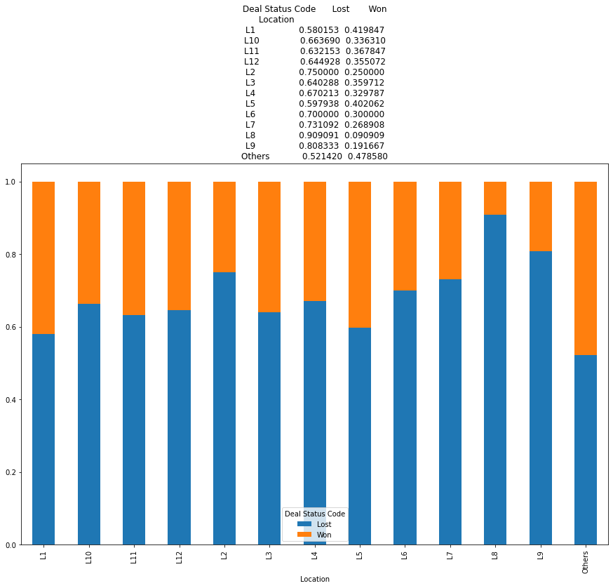

```python
BVA_categorical_plot(data,'Deal Status Code', 'Location')
```

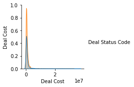

```python
#create pair plot
sns.pairplot(data=data,hue='Deal Status Code',diag_kind='kde')
plt.show()
```

Outliers in Internal category, Sector 20, 16, L10, Others Most frequent deals (Lost or Won) were observed in L, L, Others , sectors 12, 2, 23,24,9,20, Tech Service Based

## 4. Pre-processing

- Dealing With missing Values
- Remove duplicated instances
- Replace Outliers with IQR / perform logarithmic transformation
- Feature Engineering (Date ==> Month and Year / What about Name ?)
- Grouping some variables together
- One hot encoding for CLient Category / Sector /Solution Type / Location / Names
- Scaling and Normalization
- Drop Date Deal Column

```python
#Checking the null values
data.isnull().sum()
```

```
Client Category     79
Solution Type        0
Deal Date            0
Sector               0
Location             0
VP Name              0
Manager Name         0
Deal Cost            0
Deal Status Code     0
dtype: int64
```

We will impute with mode value: For the categorical column, you can replace the missing values with mode values i.e the frequent ones.

```python
data['Client Category']=data['Client Category'].fillna(data['Client Category'].mode()[0])
#data['Client Category']=data['Client Category'].fillna('Others')
```

```python
data.isnull().sum()
```

```
Client Category     0
Solution Type       0
Deal Date           0
Sector              0
Location            0
VP Name             0
Manager Name        0
Deal Cost           0
Deal Status Code    0
dtype: int64
```

```python
#Check the most frequent value in Client Category
data['Client Category'].mode()[0]
```

```
'Others'
```

```python
#Check the most frequent value in Solution Type
data['Solution Type'].mode()[0]
```

```
'Solution 32'
```

```python
#Check the most frequent value in Sector
data['Sector'].mode()[0]
```

```
'Sector 23'
```

```python
#Check the most frequent value in Location
data['Location'].mode()[0]
```

```
'L10'
```

```python
#Check the most frequent value in VP Name
data['VP Name'].mode()[0]
```

```
'Mervin\xa0Harwood'
```

```python
##Check the most frequent value in Deal Status Code
data['Deal Status Code'].mode()[0]
```

```
'Lost'
```

```python
#Check duplicated rows
data[data['Client Category']=='Energy']
```

|  | Client Category | Solution Type | Deal Date | Sector | Location | VP Name | Manager Name | Deal Cost | Deal Status Code |
| --- | --- | --- | --- | --- | --- | --- | --- | --- | --- |
| 36 | Energy | Solution 37 | 2012-02-16 | Sector 9 | L5 | Sargar Deep Rao | Sang Ingle | 294117.65 | Lost |
| 56 | Energy | Solution 6 | 2012-04-28 | Sector 9 | L5 | Sargar Deep Rao | Sang Ingle | 294117.65 | Lost |
| 102 | Energy | Solution 6 | 2012-01-21 | Sector 9 | L5 | Sargar Deep Rao | Sang Ingle | 294117.65 | Lost |
| 133 | Energy | Solution 37 | 2012-03-15 | Sector 9 | L5 | Sargar Deep Rao | Sang Ingle | 294117.65 | Lost |
| 229 | Energy | Solution 59 | 2012-02-04 | Sector 9 | L10 | Sargar Deep Rao | Anoop Jatley | 1323529.41 | Lost |
| ... | ... | ... | ... | ... | ... | ... | ... | ... | ... |
| 9735 | Energy | Solution 9 | 2018-11-11 | Sector 15 | L5 | Rahul Kocher | Sarwan Singh | 13235294.12 | Lost |
| 9760 | Energy | Solution 36 | 2019-02-03 | Sector 15 | L5 | Vikram Rawat | Ranjan Prakash | 2647058.82 | Lost |
| 9781 | Energy | Solution 36 | 2019-03-11 | Sector 15 | L5 | Vikram Rawat | Ranjan Prakash | 2647058.82 | Lost |
| 9847 | Energy | Solution 6 | 2018-11-09 | Sector 15 | L5 | Gaurav Sameria | Aman Gupta | 867647.06 | Won |
| 9888 | Energy | Solution 65 | 2018-12-11 | Sector 15 | L5 | som dutt | Siddhant Gaur | 1235294.12 | Won |

94 rows × 9 columns

```python
data.head()
```

|  | Client Category | Solution Type | Deal Date | Sector | Location | VP Name | Manager Name | Deal Cost | Deal Status Code |
| --- | --- | --- | --- | --- | --- | --- | --- | --- | --- |
| 0 | Telecom | Solution 7 | 2012-03-27 | Sector 24 | L5 | Ekta Zutshi | Gopa Trilochana | 150000.00 | Won |
| 1 | Telecom | Solution 7 | 2012-09-25 | Sector 24 | L5 | Ekta Zutshi | Gopa Trilochana | 744705.88 | Won |
| 2 | Internal | Solution 59 | 2011-08-01 | Sector 20 | Others | Ekta Zutshi | Russell Dahlen | 60000.00 | Lost |
| 3 | Internal | Solution 59 | 2011-04-28 | Sector 20 | Others | Ekta Zutshi | Russell Dahlen | 60000.00 | Lost |
| 4 | Internal | Solution 32 | 2011-06-03 | Sector 20 | Others | Ekta Zutshi | Russell Dahlen | 80882.35 | Lost |

```python
#Extract year and month information from date
data['year'] = data['Deal Date'].dt.year
data['month'] = data['Deal Date'].dt.month
```

```python
data.head()
```

|  | Client Category | Solution Type | Deal Date | Sector | Location | VP Name | Manager Name | Deal Cost | Deal Status Code | year | month |
| --- | --- | --- | --- | --- | --- | --- | --- | --- | --- | --- | --- |
| 0 | Telecom | Solution 7 | 2012-03-27 | Sector 24 | L5 | Ekta Zutshi | Gopa Trilochana | 150000.00 | Won | 2012 | 3 |
| 1 | Telecom | Solution 7 | 2012-09-25 | Sector 24 | L5 | Ekta Zutshi | Gopa Trilochana | 744705.88 | Won | 2012 | 9 |
| 2 | Internal | Solution 59 | 2011-08-01 | Sector 20 | Others | Ekta Zutshi | Russell Dahlen | 60000.00 | Lost | 2011 | 8 |
| 3 | Internal | Solution 59 | 2011-04-28 | Sector 20 | Others | Ekta Zutshi | Russell Dahlen | 60000.00 | Lost | 2011 | 4 |
| 4 | Internal | Solution 32 | 2011-06-03 | Sector 20 | Others | Ekta Zutshi | Russell Dahlen | 80882.35 | Lost | 2011 | 6 |

```python
#Check duplicated values
x=data[data.duplicated(subset=('Client Category','Solution Type','Deal Date','Sector','Location','VP Name','Manager Name','Deal Cost','Deal Status Code','year'))]
x
```

|  | Client Category | Solution Type | Deal Date | Sector | Location | VP Name | Manager Name | Deal Cost | Deal Status Code | year | month |
| --- | --- | --- | --- | --- | --- | --- | --- | --- | --- | --- | --- |
| 3036 | Domestic Public Bank | Solution 32 | 2015-03-20 | Sector 2 | L7 | Rosanna Maynez | Earline Langton | 735294.12 | Lost | 2015 | 3 |
| 3385 | Tech | Solution 32 | 2015-07-31 | Sector 2 | L10 | Long Bergstrom | Emil Knudsen | 235294.12 | Lost | 2015 | 7 |
| 3880 | Telecom | Solution 12 | 2013-08-30 | Sector 24 | Others | Mangesh K. Singh | Sohil Kumar | 588235.29 | Lost | 2013 | 8 |
| 5037 | Tech | Solution 13 | 2012-05-08 | Sector 23 | L5 | Sargar Deep Rao | Karan Dubey | 0.00 | Lost | 2012 | 5 |
| 7637 | Govt | Solution 34 | 2018-02-21 | Sector 4 | L10 | Mervin Harwood | Akshay Sharma | 602941.18 | Lost | 2018 | 2 |
| 7705 | Internal | Solution 9 | 2015-01-06 | Sector 20 | Others | Sargar Deep Rao | Brenton Launius | 2120294.12 | Lost | 2015 | 1 |
| 7718 | Services_based | Solution 26 | 2018-02-11 | Sector 17 | L10 | Molly Eakes | vansu dev | 264705.88 | Lost | 2018 | 2 |
| 8020 | Internal | Solution 9 | 2015-07-02 | Sector 2 | L9 | Sargar Deep Rao | Rahul Kocher | 264705.88 | Lost | 2015 | 7 |
| 8167 | Infrastructure | Solution 9 | 2015-05-18 | Sector 24 | L10 | Mervin Harwood | nahar singh | 352941.18 | Lost | 2015 | 5 |
| 8177 | Services_based | Solution 9 | 2015-10-03 | Sector 23 | L1 | Ankita Aggarwal | bhagwati prasad | 147058.82 | Lost | 2015 | 10 |
| 8730 | Others | Solution 9 | 2016-06-14 | Sector 23 | L4 | Rosanna Maynez | Devendra Vishvakarma | 294117.65 | Lost | 2016 | 6 |
| 8905 | Domestic Private Bank | Solution 9 | 2016-08-22 | Sector 2 | L1 | Rosanna Maynez | ram kumar | 294117.65 | Lost | 2016 | 8 |
| 9208 | International Bank | Solution 54 | 2018-08-02 | Sector 2 | L10 | Mervin Harwood | Rosana Yokum | 235294.12 | Lost | 2018 | 8 |
| 9462 | Internal | Solution 9 | 2017-12-22 | Sector 20 | Others | Hardeep Suksma | Raj Pinani | 588235.29 | Lost | 2017 | 12 |

```python
#Drop duplicated rows
data.drop_duplicates(inplace=True)
```

```python
#Drop Date column
data.drop( 'Deal Date', axis=1, inplace=True)
```

```python
#Quantile based flooring and capping of the Deal Cost variable
#### Lets compute the Interquantile range to calculate the boundaries
IQR=data['Deal Cost'].quantile(0.75)-data['Deal Cost'].quantile(0.25)
high_boundary=data['Deal Cost'].quantile(0.9)
low_boundary=data['Deal Cost'].quantile(0.1)
data['Deal Cost'] = np.where(data['Deal Cost']>high_boundary, high_boundary, data['Deal Cost'])
```

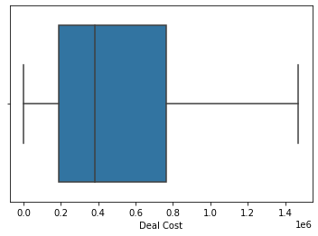

```python
sns.boxplot(x=data['Deal Cost'])
```

```python
#Scaling down the features
from sklearn.preprocessing import StandardScaler
scaler=StandardScaler()
data['Deal Cost']=scaler.fit_transform(data['Deal Cost'].values.reshape(-1, 1))
```

```python
#Cardinality of VP Name
data['VP Name'].value_counts()
```

```
Mervin Harwood         1163
Ankita Aggarwal        1142
Sargar Deep Rao         953
Long Bergstrom          920
Mangesh K. Singh        811
Rosanna Maynez          659
Ekta Zutshi             550
Rahul Bajpai            523
neeraj kumar            471
Son Mcconnaughy         232
som dutt                220
Hardeep Suksma          207
Brendon Wycoff          189
Clinton Mani            184
Saurabh Singh           176
Jewell Tunstall         156
Rudraksh Sharma         147
Gopa Trilochana         136
Russell Dahlen          133
Alam Syed               126
Molly Eakes             125
Gaurav Sameria          114
Gayle Molter            104
Varsha Arora            104
Vidur Hukle             100
Earline Langton          82
Manpreet Singh           46
Mayank Mewar             41
Rahul Kocher             32
Marcella Mo              32
Man Suddeth              29
Jitendra Choudhary       28
Prashant Rawat           27
Lilli Storrs             26
Vikram Rawat             17
Kamelesh Srinivasan      15
Dennis Faux              13
Visvajeet Das             3
Waylon Mulder             3
Kirk Hofmeister           2
md. afsar                 2
P. Somya                  2
Sarthak Batra             2
Name: VP Name, dtype: int64
```

```python
#first we make a dictionary that maps each label to the counts
VPName_freqeuncy_map=data['VP Name'].value_counts().to_dict()
ManagerName_freqeuncy_map=data['Manager Name'].value_counts().to_dict()
```

```python
VPName_freqeuncy_map
```

```
{'Mervin\xa0Harwood': 1163,
 'Ankita Aggarwal': 1142,
 'Sargar Deep Rao': 953,
 'Long\xa0Bergstrom': 920,
 'Mangesh K. Singh': 811,
 'Rosanna\xa0Maynez': 659,
 'Ekta Zutshi': 550,
 'Rahul Bajpai': 523,
 'neeraj kumar': 471,
 'Son\xa0Mcconnaughy': 232,
 'som dutt': 220,
 'Hardeep Suksma': 207,
 'Brendon\xa0Wycoff': 189,
 'Clinton\xa0Mani': 184,
 'Saurabh Singh': 176,
 'Jewell\xa0Tunstall': 156,
 'Rudraksh Sharma': 147,
 'Gopa Trilochana': 136,
 'Russell\xa0Dahlen': 133,
 'Alam Syed': 126,
 'Molly\xa0Eakes': 125,
 'Gaurav Sameria': 114,
 'Gayle\xa0Molter': 104,
 'Varsha Arora': 104,
 'Vidur Hukle': 100,
 'Earline\xa0Langton': 82,
 'Manpreet Singh': 46,
 'Mayank Mewar': 41,
 'Rahul Kocher': 32,
 'Marcella\xa0Mo': 32,
 'Man\xa0Suddeth': 29,
 'Jitendra Choudhary': 28,
 'Prashant Rawat': 27,
 'Lilli\xa0Storrs': 26,
 'Vikram Rawat': 17,
 'Kamelesh Srinivasan': 15,
 'Dennis\xa0Faux': 13,
 'Visvajeet Das': 3,
 'Waylon\xa0Mulder': 3,
 'Kirk\xa0Hofmeister': 2,
 'md. afsar': 2,
 'P. Somya': 2,
 'Sarthak Batra': 2}
```

```python
ManagerName_freqeuncy_map
```

```
{'Molly\xa0Eakes': 323,
 'Rudraksh Sharma': 270,
 'Desmond\xa0Krout': 230,
 'Gayle\xa0Molter': 186,
 'Manpreet Singh': 181,
 'Rosana\xa0Yokum': 179,
 'Rayford\xa0Durgan': 170,
 'Manish Saundriyal': 160,
 'Jewell\xa0Tunstall': 159,
 'Hardeep Suksma': 151,
 'ram kumar': 148,
 'Rahul Kocher': 144,
 'Russell\xa0Dahlen': 143,
 'Marcella\xa0Mo': 137,
 'Atul Chaudhary': 134,
 'vansu dev': 131,
 'Roop Sachdeva': 127,
 'Harsh Verma': 127,
 'Clinton\xa0Mani': 120,
 'Vinay Kumar': 118,
 'rohit': 118,
 'Tanuj Bindra': 114,
 'Karna Bhuvennant': 112,
 'nahar singh': 108,
 'Vidur Hukle': 107,
 'Ayusha Gupta': 106,
 'Saurabh Singh': 103,
 'Shalendra D.': 99,
 'bhagwati prasad': 98,
 'David Toms': 97,
 'Jean\xa0Sappington': 96,
 'Abhinav Warrier': 95,
 'Darin\xa0Vath': 94,
 'Abhiskek Kumar': 94,
 'Eesha Yadav': 92,
 'mohd shakib': 89,
 'Gaurav Sameria': 89,
 'Jackie\xa0Wolfson': 88,
 'Rajneesh Tanwar': 86,
 'Gopa Trilochana': 86,
```

[output cut: 223 more lines]

```
 'Rishab Bhatt': 1,
 'Sultan Khan': 1,
 'Preston\xa0Dumire': 1,
 'Brenton\xa0Launius': 1,
 'Aastha Gandhi': 1,
 'Jayant Kalra': 1,
 'Anish Jonson': 1,
 'Lokesh Pinani': 1,
 'Sumit Arora': 1,
 'Cori\xa0Gillispie': 1,
 'Heath\xa0Mullarkey': 1,
 'Palmer\xa0Holmberg': 1,
 'Arti Bindra': 1,
 'Anju Nanda': 1,
 'Ali Rafiq': 1}
```

```python
# and now we replace both VP name and Manager Name labels in the dataset df
#data['VP_name_encoded'] = data['VP Name'].map(VPName_freqeuncy_map)
data['Manager_name_encoded'] = data['Manager Name'].map(ManagerName_freqeuncy_map)
```

```python
#Encode the target variable as Won: 1 and Lost 0
data['Deal Status Code']=data['Deal Status Code'].replace({'Lost': 0, 'Won':1})
```

```python
data.head()
```

|  | Client Category | Solution Type | Sector | Location | VP Name | Manager Name | Deal Cost | Deal Status Code | year | month | Manager_name_encoded |
| --- | --- | --- | --- | --- | --- | --- | --- | --- | --- | --- | --- |
| 0 | Telecom | Solution 7 | Sector 24 | L5 | Ekta Zutshi | Gopa Trilochana | -0.855994 | 1 | 2012 | 3 | 86 |
| 1 | Telecom | Solution 7 | Sector 24 | L5 | Ekta Zutshi | Gopa Trilochana | 0.453151 | 1 | 2012 | 9 | 86 |
| 2 | Internal | Solution 59 | Sector 20 | Others | Ekta Zutshi | Russell Dahlen | -1.054114 | 0 | 2011 | 8 | 143 |
| 3 | Internal | Solution 59 | Sector 20 | Others | Ekta Zutshi | Russell Dahlen | -1.054114 | 0 | 2011 | 4 | 143 |
| 4 | Internal | Solution 32 | Sector 20 | Others | Ekta Zutshi | Russell Dahlen | -1.008145 | 0 | 2011 | 6 | 143 |

```python
data['Sector'].value_counts()
```

```
Sector 23    2690
Sector 2     1743
Sector 20     771
Sector 12     607
Sector 24     576
Sector 16     474
Sector 17     473
Sector 15     387
Sector 9      369
Sector 25     273
Sector 18     251
Sector 1      231
Sector 13     185
Sector 22     144
Sector 19     142
Sector 3      135
Sector 4      127
Sector 11     114
Sector 14     109
Sector 6       96
Sector 5       64
Sector 8       39
Sector 21      30
Sector 7       14
Sector 10       3
Name: Sector, dtype: int64
```

```python
#Number of unique labels in each categorical variables
for col in Names_data+ cat_data:
    print(col, ': ', len(data[col].unique()), ' labels')
```

```
VP Name :  43  labels
Manager Name :  278  labels
Client Category :  40  labels
Solution Type :  67  labels
Sector :  25  labels
Location :  13  labels
```

```python
#Copy the orignal datase into new data
train=data.copy()
#+ ['VP Name', 'Manager Name']
#One hot encoding on the categorical variables
for column in cat_data +['VP Name']:
    tempdata = pd.get_dummies(train[column], prefix=column)
    train = pd.merge(
        left=train,
        right=tempdata,
        left_index=True,
        right_index=True,
    )
    train.drop(columns=column, inplace=True)
#train.drop(columns=['Manager Name'], inplace=True)
```

```python
train
```

|  | Manager Name | Deal Cost | Deal Status Code | year | month | Manager_name_encoded | Client Category_Airpline | Client Category_Automobiles | Client Category_Consulting | Client Category_Consumer Good | Client Category_Domestic Bank | Client Category_Domestic Private Bank | Client Category_Domestic Public Bank | Client Category_Electronics | Client Category_Energy | Client Category_Finance | Client Category_Govt | Client Category_Govt Bank Special | Client Category_Healthcare | Client Category_Holding | Client Category_Hospitality | Client Category_Industries | Client Category_Infrastructure | Client Category_Insurance | Client Category_Internal | Client Category_International Bank | Client Category_International Org | Client Category_Knowledge | Client Category_Logistics | … |
| --- | --- | --- | --- | --- | --- | --- | --- | --- | --- | --- | --- | --- | --- | --- | --- | --- | --- | --- | --- | --- | --- | --- | --- | --- | --- | --- | --- | --- | --- | --- |
| 0 | Gopa Trilochana | -0.855994 | 1 | 2012 | 3 | 86 | 0 | 0 | 0 | 0 | 0 | 0 | 0 | 0 | 0 | 0 | 0 | 0 | 0 | 0 | 0 | 0 | 0 | 0 | 0 | 0 | 0 | 0 | 0 | … |
| 1 | Gopa Trilochana | 0.453151 | 1 | 2012 | 9 | 86 | 0 | 0 | 0 | 0 | 0 | 0 | 0 | 0 | 0 | 0 | 0 | 0 | 0 | 0 | 0 | 0 | 0 | 0 | 0 | 0 | 0 | 0 | 0 | … |
| 2 | Russell Dahlen | -1.054114 | 0 | 2011 | 8 | 143 | 0 | 0 | 0 | 0 | 0 | 0 | 0 | 0 | 0 | 0 | 0 | 0 | 0 | 0 | 0 | 0 | 0 | 0 | 1 | 0 | 0 | 0 | 0 | … |
| 3 | Russell Dahlen | -1.054114 | 0 | 2011 | 4 | 143 | 0 | 0 | 0 | 0 | 0 | 0 | 0 | 0 | 0 | 0 | 0 | 0 | 0 | 0 | 0 | 0 | 0 | 0 | 1 | 0 | 0 | 0 | 0 | … |
| 4 | Russell Dahlen | -1.008145 | 0 | 2011 | 6 | 143 | 0 | 0 | 0 | 0 | 0 | 0 | 0 | 0 | 0 | 0 | 0 | 0 | 0 | 0 | 0 | 0 | 0 | 0 | 1 | 0 | 0 | 0 | 0 | … |
| ... | ... | ... | ... | ... | ... | ... | ... | ... | ... | ... | ... | ... | ... | ... | ... | ... | ... | ... | ... | ... | ... | ... | ... | ... | ... | ... | ... | ... | ... | … |
| 10056 | Rudraksh Sharma | 0.108707 | 0 | 2019 | 3 | 270 | 0 | 0 | 0 | 0 | 0 | 0 | 0 | 0 | 0 | 0 | 0 | 0 | 0 | 0 | 0 | 0 | 0 | 0 | 0 | 0 | 0 | 0 | 0 | … |
| 10057 | Sharavan Singh | 0.524370 | 1 | 2019 | 3 | 15 | 0 | 0 | 0 | 0 | 0 | 0 | 0 | 0 | 0 | 0 | 0 | 0 | 0 | 0 | 0 | 0 | 0 | 0 | 1 | 0 | 0 | 0 | 0 | … |
| 10058 | Rudraksh Sharma | 0.108707 | 0 | 2019 | 2 | 270 | 0 | 0 | 0 | 0 | 0 | 0 | 0 | 0 | 0 | 0 | 0 | 0 | 0 | 0 | 0 | 0 | 0 | 0 | 0 | 0 | 0 | 0 | 0 | … |
| 10059 | Cleotilde Biron | 2.051058 | 1 | 2019 | 1 | 1 | 0 | 0 | 0 | 0 | 0 | 0 | 0 | 0 | 0 | 0 | 0 | 0 | 0 | 0 | 0 | 0 | 0 | 0 | 0 | 0 | 0 | 0 | 0 | … |
| 10060 | Tarun Garg | -0.862468 | 0 | 2019 | 5 | 71 | 0 | 0 | 0 | 0 | 0 | 0 | 0 | 0 | 0 | 0 | 0 | 0 | 0 | 0 | 0 | 0 | 0 | 0 | 0 | 0 | 0 | 0 | 0 | … |

10047 rows × 194 columns

```python
train.drop(columns=['Manager Name'], inplace=True)
```

```python
cat_data
```

```
['Client Category', 'Solution Type', 'Sector', 'Location']
```

```python
#Test data
y=train['Deal Status Code'].to_numpy()
#Train data
X=train.drop(columns=['Deal Status Code'], inplace=True)
```

```python
X=train.to_numpy()
X.shape
```

```
(10047, 192)
```

```python
#Split dataset into train (70%) and test data (30%)
from sklearn.model_selection import train_test_split
trainX, testX, trainY, testY = train_test_split(X,y,test_size=0.30, random_state=0, stratify=y)
```

## Model Building

```python
from sklearn.model_selection import cross_val_score
from sklearn.naive_bayes import GaussianNB
from sklearn.linear_model import LogisticRegression
from sklearn import tree
from sklearn.neighbors import KNeighborsClassifier
from sklearn.ensemble import RandomForestClassifier
from sklearn.svm import SVC
from xgboost.sklearn import XGBClassifier
#Common Model Algorithms
from sklearn import svm, tree, linear_model, neighbors, naive_bayes, ensemble, discriminant_analysis, gaussian_process
from xgboost import XGBClassifier
import lightgbm as lgb
#Common Model Helpers
from sklearn.preprocessing import OneHotEncoder, LabelEncoder
from sklearn import feature_selection
from sklearn import model_selection
from sklearn import metrics
from sklearn.model_selection import KFold
```

```python
#Machine Learning Algorithm (MLA) Selection and Initialization
base_models = [
    #Ensemble Methods
    ensemble.AdaBoostClassifier(random_state=0),
    #max_depth=6,
    ensemble.ExtraTreesClassifier(random_state=0),
    ensemble.GradientBoostingClassifier(random_state=0),
    #max_depth=5,
    ensemble.RandomForestClassifier(random_state=0),

    #Gaussian Processes
   #gaussian_process.GaussianProcessClassifier(),

    #GLM
    #linear_model.LogisticRegressionCV(),
    #Navies Bayes
    #naive_bayes.BernoulliNB(),
    #naive_bayes.GaussianNB(),

    #Nearest Neighbor
    #neighbors.KNeighborsClassifier(),

    #SVM
    #svm.SVC(probability=True),

    #Trees   max_depth=6,
    tree.DecisionTreeClassifier(random_state=0),
    #tree.ExtraTreeClassifier(),

    #xgboost: http://xgboost.readthedocs.io/en/latest/model.html
    #XGBClassifier(max_depth=4, eta=0.05, gamma=4),
    XGBClassifier(),
    #lgb.LGBMClassifier(random_state=0)
    #lgb.LGBMClassifier(max_depth=4, learning_rate=0.05, random_state=0)
    ]
```

```python
def model_cross_val(n_folds,X,y, base_models):
    #kfold = model_selection.ShuffleSplit(n_splits = 10, test_size = .3, train_size = .6, random_state = 0 )
    #kfold = KFold(n_splits=n_folds, shuffle=True, random_state=156)
    #index through MLA and save performance to table
    row_index = 0
    #create table to compare MLA metrics
    MLA_columns = ['MLA Name', 'MLA Parameters', 'MLA Test Accuracy Mean', 'MLA Test Accuracy 3*STD' ,'MLA Time']
    MLA_compare = pd.DataFrame(columns = MLA_columns)
    for alg in base_models:
        #set name and parameters
        MLA_name = alg.__class__.__name__
        MLA_compare.loc[row_index, 'MLA Name'] = MLA_name
        MLA_compare.loc[row_index, 'MLA Parameters'] = str(alg.get_params())
        scores = model_selection.cross_validate(alg, X, y, scoring='accuracy',cv  = n_folds)
        MLA_compare.loc[row_index, 'MLA Time'] =scores['fit_time'].mean()
        #MLA_compare.loc[row_index, 'MLA Train Accuracy Mean'] = scores['train_score'].mean()
        MLA_compare.loc[row_index, 'MLA Test Accuracy Mean'] = scores['test_score'].mean()
        #if this is a non-bias random sample, then +/-3 standard deviations (std) from the mean, should statistically capture 99.7% of the subsets
        MLA_compare.loc[row_index, 'MLA Test Accuracy 3*STD'] = scores['test_score'].std()*3   #let's know the worst that can happen!
        #alg.fit(X_train, y_train)
        #y_pred = alg.predict(X_val)
        row_index+=1
        #print and sort table: https://pandas.pydata.org/pandas-docs/stable/generated/pandas.DataFrame.sort_values.html
    MLA_compare.sort_values(by = ['MLA Test Accuracy Mean'], ascending = False, inplace = True)
        #print and sort table: https://pandas.pydata.org/pandas-docs/stable/generated/pandas.DataFrame.sort_values.html

    return MLA_compare

#MLA_predict
```

## Benchmark Model

```python
#max_depth, min_child_weight and gamma.
#base_models=[lgb.LGBMClassifier(max_depth=4, learning_rate=0.05, random_state=0)]
n_folds=10
#Benchmark Model
mod=model_cross_val(n_folds,trainX, trainY, base_models)
mod
```

[output not shown]

|  | MLA Name | MLA Parameters | MLA Test Accuracy Mean | MLA Test Accuracy 3*STD | MLA Time |
| --- | --- | --- | --- | --- | --- |
| 3 | RandomForestClassifier | {'bootstrap': True, 'ccp_alpha': 0.0, 'class_w... | 0.782705 | 0.04437 | 1.142639 |
| 1 | ExtraTreesClassifier | {'bootstrap': False, 'ccp_alpha': 0.0, 'class_... | 0.774883 | 0.050819 | 1.406756 |
| 5 | XGBClassifier | {'objective': 'binary:logistic', 'use_label_en... | 0.762653 | 0.036732 | 1.51425 |
| 4 | DecisionTreeClassifier | {'ccp_alpha': 0.0, 'class_weight': None, 'crit... | 0.744736 | 0.054311 | 0.098734 |
| 2 | GradientBoostingClassifier | {'ccp_alpha': 0.0, 'criterion': 'friedman_mse'... | 0.705909 | 0.055494 | 2.211805 |
| 0 | AdaBoostClassifier | {'algorithm': 'SAMME.R', 'base_estimator': Non... | 0.699511 | 0.039266 | 0.772143 |

```python
#correlation heatmap of dataset
#import seaborn as sns
#corr=train.corr()
#top_features=corr.index
#plt.figure(figsize=(20,20))
#sns.heatmap(train[top_features].corr(),annot=True)
```

```python
#Remove correlated features
# Set the threshold
threshold = 0.8

def correlation(dataset, threshold):
    col_corr = set()  # Set of all the names of correlated columns
    corr_matrix = dataset.corr()
    for i in range(len(corr_matrix.columns)):
        for j in range(i):
            if abs(corr_matrix.iloc[i, j]) > threshold: # we are interested in absolute coeff value
                colname = corr_matrix.columns[i]  # getting the name of column
                col_corr.add(colname)
    return col_corr
```

```python
a=correlation(train,threshold)
```

```python
print('Columns to remove : ', a)
```

```
Columns to remove :  {'VP Name_Waylon\xa0Mulder', 'VP Name_Kirk\xa0Hofmeister'}
```

```python
train.drop(columns=a , inplace=True)
```

```python
train
```

|  | Deal Cost | year | month | Manager_name_encoded | Client Category_Airpline | Client Category_Automobiles | Client Category_Consulting | Client Category_Consumer Good | Client Category_Domestic Bank | Client Category_Domestic Private Bank | Client Category_Domestic Public Bank | Client Category_Electronics | Client Category_Energy | Client Category_Finance | Client Category_Govt | Client Category_Govt Bank Special | Client Category_Healthcare | Client Category_Holding | Client Category_Hospitality | Client Category_Industries | Client Category_Infrastructure | Client Category_Insurance | Client Category_Internal | Client Category_International Bank | Client Category_International Org | Client Category_Knowledge | Client Category_Logistics | Client Category_Management | Client Category_Manufacturing | … |
| --- | --- | --- | --- | --- | --- | --- | --- | --- | --- | --- | --- | --- | --- | --- | --- | --- | --- | --- | --- | --- | --- | --- | --- | --- | --- | --- | --- | --- | --- | --- |
| 0 | -0.855994 | 2012 | 3 | 86 | 0 | 0 | 0 | 0 | 0 | 0 | 0 | 0 | 0 | 0 | 0 | 0 | 0 | 0 | 0 | 0 | 0 | 0 | 0 | 0 | 0 | 0 | 0 | 0 | 0 | … |
| 1 | 0.453151 | 2012 | 9 | 86 | 0 | 0 | 0 | 0 | 0 | 0 | 0 | 0 | 0 | 0 | 0 | 0 | 0 | 0 | 0 | 0 | 0 | 0 | 0 | 0 | 0 | 0 | 0 | 0 | 0 | … |
| 2 | -1.054114 | 2011 | 8 | 143 | 0 | 0 | 0 | 0 | 0 | 0 | 0 | 0 | 0 | 0 | 0 | 0 | 0 | 0 | 0 | 0 | 0 | 0 | 1 | 0 | 0 | 0 | 0 | 0 | 0 | … |
| 3 | -1.054114 | 2011 | 4 | 143 | 0 | 0 | 0 | 0 | 0 | 0 | 0 | 0 | 0 | 0 | 0 | 0 | 0 | 0 | 0 | 0 | 0 | 0 | 1 | 0 | 0 | 0 | 0 | 0 | 0 | … |
| 4 | -1.008145 | 2011 | 6 | 143 | 0 | 0 | 0 | 0 | 0 | 0 | 0 | 0 | 0 | 0 | 0 | 0 | 0 | 0 | 0 | 0 | 0 | 0 | 1 | 0 | 0 | 0 | 0 | 0 | 0 | … |
| ... | ... | ... | ... | ... | ... | ... | ... | ... | ... | ... | ... | ... | ... | ... | ... | ... | ... | ... | ... | ... | ... | ... | ... | ... | ... | ... | ... | ... | ... | … |
| 10056 | 0.108707 | 2019 | 3 | 270 | 0 | 0 | 0 | 0 | 0 | 0 | 0 | 0 | 0 | 0 | 0 | 0 | 0 | 0 | 0 | 0 | 0 | 0 | 0 | 0 | 0 | 0 | 0 | 0 | 0 | … |
| 10057 | 0.524370 | 2019 | 3 | 15 | 0 | 0 | 0 | 0 | 0 | 0 | 0 | 0 | 0 | 0 | 0 | 0 | 0 | 0 | 0 | 0 | 0 | 0 | 1 | 0 | 0 | 0 | 0 | 0 | 0 | … |
| 10058 | 0.108707 | 2019 | 2 | 270 | 0 | 0 | 0 | 0 | 0 | 0 | 0 | 0 | 0 | 0 | 0 | 0 | 0 | 0 | 0 | 0 | 0 | 0 | 0 | 0 | 0 | 0 | 0 | 0 | 0 | … |
| 10059 | 2.051058 | 2019 | 1 | 1 | 0 | 0 | 0 | 0 | 0 | 0 | 0 | 0 | 0 | 0 | 0 | 0 | 0 | 0 | 0 | 0 | 0 | 0 | 0 | 0 | 0 | 0 | 0 | 0 | 0 | … |
| 10060 | -0.862468 | 2019 | 5 | 71 | 0 | 0 | 0 | 0 | 0 | 0 | 0 | 0 | 0 | 0 | 0 | 0 | 0 | 0 | 0 | 0 | 0 | 0 | 0 | 0 | 0 | 0 | 0 | 0 | 0 | … |

10047 rows × 190 columns

## Feature Selection using Information gain

```python
trainX=[]
testX=[]
trainY=[]
testY=[]
X=train

#SPlit dataset into train (70%) and test data (30%)
from sklearn.model_selection import train_test_split
trainX, testX, trainY, testY = train_test_split(X,y,test_size=0.30, random_state=0, stratify=y)
```

```python
from sklearn.feature_selection import mutual_info_classif
# determine the mutual information
mutual_info = mutual_info_classif(trainX, trainY)
mutual_info = pd.Series(mutual_info)
mutual_info.index = trainX.columns
mutual_info.sort_values(ascending=False)
```

```
Deal Cost                    0.085428
Manager_name_encoded         0.029037
Solution Type_Solution 9     0.015854
Location_L8                  0.014630
Solution Type_Solution 45    0.011875
                               ...
Sector_Sector 6              0.000000
Solution Type_Solution 22    0.000000
Solution Type_Solution 23    0.000000
Solution Type_Solution 25    0.000000
VP Name_som dutt             0.000000
Length: 190, dtype: float64
```

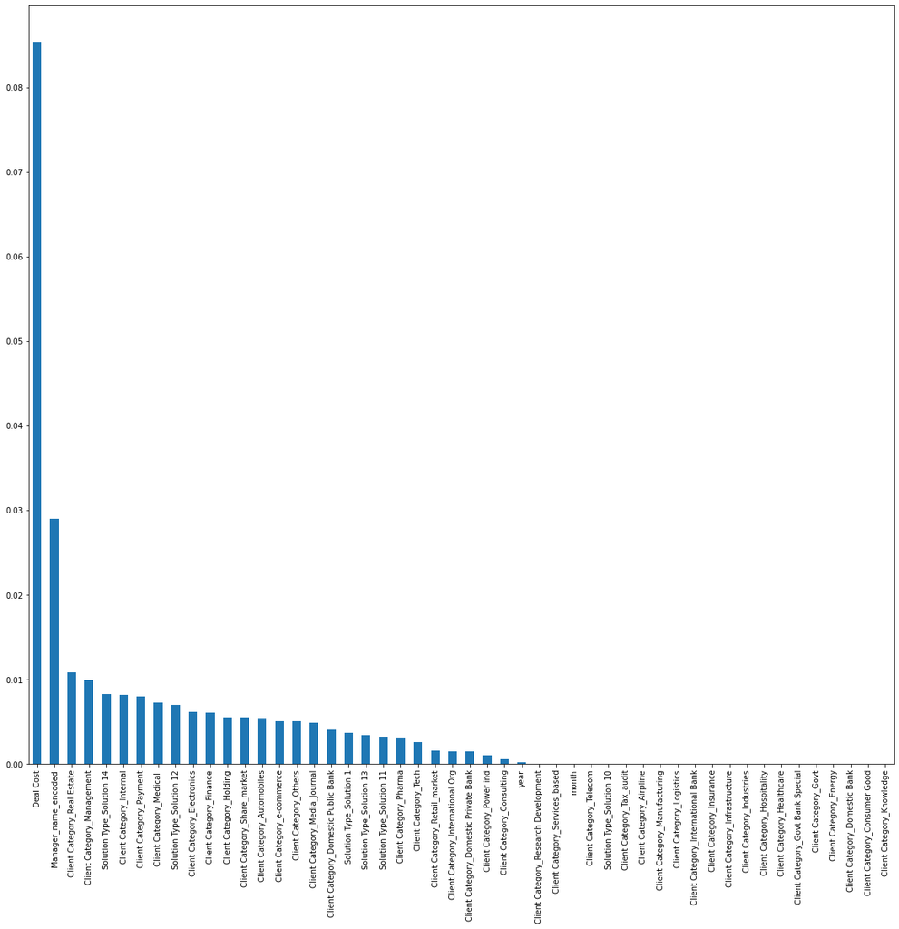

```python
#let's plot the ordered mutual_info values per feature
mutual_info[0:50].sort_values(ascending=False).plot.bar(figsize=(20, 18))
```

```python
from sklearn.feature_selection import SelectKBest
```

```python
from sklearn.metrics import accuracy_score
base_model_test=ensemble.RandomForestClassifier(random_state=0)
```

```python
#Select features using mutual information gain
#No we Will select the  top 24 important features
base_model_test=[]
base_model_test=ensemble.RandomForestClassifier(random_state=0)
num=180
#acc=[]
#for num in range(10,190,10):
sel_five_cols = SelectKBest(mutual_info_classif, k=num)
sel_five_cols.fit(trainX, trainY)
trainX[trainX.columns[sel_five_cols.get_support()]]

scores = model_selection.cross_validate(base_model_test, trainX[trainX.columns[sel_five_cols.get_support()]] , trainY, scoring='accuracy',cv =10)
#    acc.append(scores['test_score'].mean())
acc=scores['test_score'].mean()
#base_model_test.fit( trainX[trainX.columns[sel_five_cols.get_support()]].to_numpy() ,trainY)
#pred_test_y = base_model_test.predict(testX[testX.columns[sel_five_cols.get_support()]].to_numpy())
#acc= accuracy_score(testY, pred_test_y)
print("Accuracy Vector: ", acc )
```

```
Accuracy Vector:  0.7778679846114056
```

## Model Tuning with Randomized Search

```python
#fucntion for the selection the best parameters of a model
def clf_performance(classifier, model_name):
    print(model_name)
    print('Best Score: ' + str(classifier.best_score_))
    print('Best Parameters: ' + str(classifier.best_params_))
```

```python
#Running the new model
rf = RandomForestClassifier(n_estimators=1000, min_samples_split=2, min_samples_leaf=1, max_features='sqrt', max_depth=None, bootstrap= False,random_state = 1)
```

```python
rf.fit( trainX[trainX.columns[sel_five_cols.get_support()]].to_numpy() ,trainY)
pred_test_y = rf.predict(testX[testX.columns[sel_five_cols.get_support()]].to_numpy())
acc= accuracy_score(testY, pred_test_y)
print("Accuracy Vector: ", acc )
```

```
Accuracy Vector:  0.8069651741293532
```

## Model Performance

```python
 from sklearn.metrics import plot_roc_curve, plot_confusion_matrix, classification_report, plot_precision_recall_curve
```

```
The accuracy of RandomForestClassifier(bootstrap=False, max_features='sqrt', n_estimators=1000,
                       random_state=1) model is 0.81


CLASSIFICATION REPORT
               precision    recall  f1-score   support

           0       0.80      0.92      0.86      1888
           1       0.82      0.62      0.71      1127

    accuracy                           0.81      3015
   macro avg       0.81      0.77      0.78      3015
weighted avg       0.81      0.81      0.80      3015


CONFUSION MATRIX
```

```
<sklearn.metrics._plot.precision_recall_curve.PrecisionRecallDisplay at 0x172bca9be50>
```

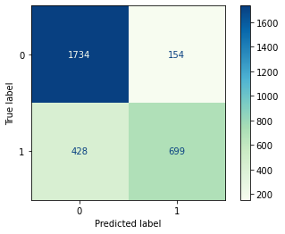

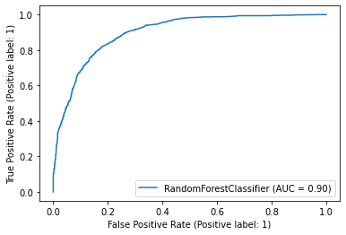

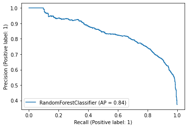

```python
print('The accuracy of {} model is {}'.format(rf, accuracy_score(testY, pred_test_y).round(2)))
print("\n")
print("CLASSIFICATION REPORT",'\n',classification_report(testY, pred_test_y),"\n")
print("CONFUSION MATRIX",'\n')
plot_confusion_matrix(rf, testX[testX.columns[sel_five_cols.get_support()]], testY, cmap = "GnBu")
plot_roc_curve(rf,testX[testX.columns[sel_five_cols.get_support()]],testY)
plot_precision_recall_curve(rf,testX[testX.columns[sel_five_cols.get_support()]],testY)
```

## Recommendation of top 5 VP and Manager Names

1. We take the Pair securing the maximum delas
2. We take the pairs with highest win probability

```python
data_orig.head()
#Encode the target variable as Won: 1 and Lost 0
data_orig['Deal Status Code']=data_orig['Deal Status Code'].replace({'Lost': 0, 'Won':1})
```

```python
# Subsetting the data correpsonding to the won deals
Data_won_deals = data_orig[data_orig['Deal Status Code']== 1]
Data_won_deals.shape
```

```
(3755, 9)
```

```python
Data_won_deals
```

|  | Client Category | Solution Type | Deal Date | Sector | Location | VP Name | Manager Name | Deal Cost | Deal Status Code |
| --- | --- | --- | --- | --- | --- | --- | --- | --- | --- |
| 0 | Telecom | Solution 7 | 2012-03-27 | Sector 24 | L5 | Ekta Zutshi | Gopa Trilochana | 150000.00 | 1 |
| 1 | Telecom | Solution 7 | 2012-09-25 | Sector 24 | L5 | Ekta Zutshi | Gopa Trilochana | 744705.88 | 1 |
| 6 | Internal | Solution 59 | 2011-11-03 | Sector 2 | L10 | Mervin Harwood | rahul sharma | 526176.47 | 1 |
| 8 | Consumer Good | Solution 42 | 2012-04-11 | Sector 12 | L10 | Lilli Storrs | Md. Daud | 1032352.94 | 1 |
| 10 | International Bank | Solution 6 | 2012-02-11 | Sector 2 | L10 | Long Bergstrom | Luv Malhotra | 316176.47 | 1 |
| ... | ... | ... | ... | ... | ... | ... | ... | ... | ... |
| 10051 | Power ind | Solution 4 | 2018-12-25 | Sector 9 | L5 | Alam Syed | Rateesh Singh | 1404411.77 | 1 |
| 10053 | Power ind | Solution 9 | 2019-03-25 | Sector 9 | L5 | Man Suddeth | Jose Gamber | 3462058.82 | 1 |
| 10054 | Telecom | Solution 4 | 2019-01-23 | Sector 24 | L5 | Rahul Bajpai | Abhiskek Kumar | 58823.53 | 1 |
| 10057 | Internal | Solution 6 | 2019-03-04 | Sector 20 | Others | Rudraksh Sharma | Sharavan Singh | 777058.82 | 1 |
| 10059 | Power ind | Solution 62 | 2019-01-27 | Sector 9 | L5 | Man Suddeth | Cleotilde Biron | 3042058.82 | 1 |

3755 rows × 9 columns

```python
# We group data by Manager and VP Names, then assign the maxi deal to each group and the number of won deals
n=5
col_names = {'Deal Cost':'Total Deal Cost', 'Deal Status Code': 'Total Deals'}
temp_df = Data_won_deals.groupby(['VP Name', 'Manager Name']).agg({'Deal Cost':'max', 'Deal Status Code': 'sum'}).rename(columns=col_names).sort_values(by='Total Deal Cost', ascending=False).head(n)
temp_df
```

| VP Name | Manager Name | Total Deal Cost | Total Deals |
| --- | --- | --- | --- |
| Varsha Arora | Rahul Singh | 36764705.88 | 6 |
|  | Sarwan Singh | 26352941.18 | 6 |
| Mangesh K. Singh | Vinay Kumar | 25000000.00 | 3 |
| Brendon Wycoff | vansu dev | 24823529.41 | 10 |
| Mangesh K. Singh | Zulema Perrine | 24630882.35 | 9 |

1. We take the pairs with highest probability win

```python
#Rename some columns of the orirgin dataframe
data=data.rename(columns={"Deal Status Code": "Deal_Status_Code", "Manager Name": "Manager_Name", "VP Name": "VP_Name"}, errors="raise")
```

```python
data.head(15)
```

|  | Client Category | Solution Type | Sector | Location | VP_Name | Manager_Name | Deal Cost | Deal_Status_Code | year | month | Manager_name_encoded |
| --- | --- | --- | --- | --- | --- | --- | --- | --- | --- | --- | --- |
| 0 | Telecom | Solution 7 | Sector 24 | L5 | Ekta Zutshi | Gopa Trilochana | -0.855994 | 1 | 2012 | 3 | 86 |
| 1 | Telecom | Solution 7 | Sector 24 | L5 | Ekta Zutshi | Gopa Trilochana | 0.453151 | 1 | 2012 | 9 | 86 |
| 2 | Internal | Solution 59 | Sector 20 | Others | Ekta Zutshi | Russell Dahlen | -1.054114 | 0 | 2011 | 8 | 143 |
| 3 | Internal | Solution 59 | Sector 20 | Others | Ekta Zutshi | Russell Dahlen | -1.054114 | 0 | 2011 | 4 | 143 |
| 4 | Internal | Solution 32 | Sector 20 | Others | Ekta Zutshi | Russell Dahlen | -1.008145 | 0 | 2011 | 6 | 143 |
| 5 | Internal | Solution 32 | Sector 20 | Others | Ekta Zutshi | Russell Dahlen | -1.008145 | 0 | 2011 | 5 | 143 |
| 6 | Internal | Solution 59 | Sector 2 | L10 | Mervin Harwood | rahul sharma | -0.027905 | 1 | 2011 | 11 | 6 |
| 7 | Govt | Solution 7 | Sector 13 | L5 | Sargar Deep Rao | Vidur Hukle | -0.284295 | 0 | 2012 | 9 | 107 |
| 8 | Consumer Good | Solution 42 | Sector 12 | L10 | Lilli Storrs | Md. Daud | 1.086357 | 1 | 2012 | 4 | 25 |
| 9 | Internal | Solution 59 | Sector 20 | Others | Sargar Deep Rao | Hardeep Suksma | 0.043962 | 0 | 2011 | 11 | 151 |
| 10 | International Bank | Solution 6 | Sector 2 | L10 | Long Bergstrom | Luv Malhotra | -0.490184 | 1 | 2012 | 2 | 83 |
| 11 | Domestic Public Bank | Solution 59 | Sector 2 | L11 | Mervin Harwood | Lino Batterton | 0.859750 | 1 | 2012 | 3 | 65 |
| 12 | Finance | Solution 59 | Sector 2 | L5 | Mervin Harwood | Sang Ingle | 2.051058 | 1 | 2012 | 4 | 33 |
| 13 | Manufacturing | Solution 59 | Sector 15 | L5 | Ekta Zutshi | shafibul | 2.051058 | 0 | 2011 | 12 | 12 |
| 14 | Finance | Solution 20 | Sector 17 | L5 | Long Bergstrom | Anand S. Pandey | -0.917502 | 0 | 2011 | 12 | 46 |

```python
#Group by Manager and VP names
A=data.groupby([ 'VP_Name' ,'Manager_Name']).Deal_Status_Code.value_counts(normalize=False).unstack()
```

```python
A
```

| VP_Name | Deal_Status_Code Manager_Name | 0 | 1 |
| --- | --- | --- | --- |
| Alam Syed | Abhinav Warrier | 2.0 | NaN |
|  | Alam Syed | NaN | 2.0 |
|  | Darin Vath | 8.0 | 17.0 |
|  | Deepak Chandra Prakash | 8.0 | 6.0 |
|  | Dennis Faux | NaN | 1.0 |
| ... | ... | ... | ... |
| som dutt | mohd khairul | 10.0 | 5.0 |
|  | nahar singh | 16.0 | 9.0 |
|  | ram dutt gupta | NaN | 1.0 |
|  | sheak shakir | 2.0 | 3.0 |
|  | som dutt | NaN | 2.0 |

960 rows × 2 columns

```python
#Replace NaN values with  0
#A=A.fillna(0)
```

```python
#Calculate the probability win
A['prob_win']=A[1]/(A[0]+A[1])
```

```python
A.sort_values('prob_win', ascending=False).head(10)
```

| VP_Name | Deal_Status_Code Manager_Name | 0 | 1 | prob_win |
| --- | --- | --- | --- | --- |
| Ekta Zutshi | Manpreet Singh | 2.0 | 20.0 | 0.909091 |
| Long Bergstrom | Akshit Khanna | 2.0 | 16.0 | 0.888889 |
| Rahul Bajpai | Jitendra Choudhary | 2.0 | 15.0 | 0.882353 |
| Ekta Zutshi | neeraj kumar | 6.0 | 40.0 | 0.869565 |
| Hardeep Suksma | Atul Chaudhary | 2.0 | 13.0 | 0.866667 |
| Long Bergstrom | Rayford Durgan | 4.0 | 23.0 | 0.851852 |
| Earline Langton | Neha Sharma | 2.0 | 9.0 | 0.818182 |
| Hardeep Suksma | ram kumar | 2.0 | 9.0 | 0.818182 |
| Ekta Zutshi | Chanchal sharma | 4.0 | 17.0 | 0.809524 |
| Long Bergstrom | Naveen Dogra | 2.0 | 8.0 | 0.800000 |